# Job Skills Analysis

```python
# import os
import pandas as pd
import seaborn as sns
from collections import Counter
import matplotlib.pyplot as plt
%run utils.ipynb
```

### Load data

```python
df = pd.read_csv('salary_vis2.csv', index_col=[0])
# df = pd.read_csv('complete_refined.csv', index_col=[0])
```

### Exam the charasteristics of the dataset

```python
df['required_skills'].apply(type)
```

```
0       <class 'str'>
1       <class 'str'>
2       <class 'str'>
3       <class 'str'>
6       <class 'str'>
            ...
1501    <class 'str'>
1503    <class 'str'>
1505    <class 'str'>
1507    <class 'str'>
1510    <class 'str'>
Name: required_skills, Length: 766, dtype: object
```

```python
## split lists of skills to single skill rows
df2 = df[df['required_skills'].notna()].copy()
df2['required_skills'] = df2['required_skills'].apply(eval)
df2['required_skills'].info()
```

```
<class 'pandas.core.series.Series'>
Int64Index: 765 entries, 0 to 1510
Series name: required_skills
Non-Null Count  Dtype
--------------  -----
765 non-null    object
dtypes: object(1)
memory usage: 12.0+ KB
```

```python
# tranform the lists of required skills to rows of single skill
exploded_df = df2.explode('required_skills')
# standardize all letters to lower, generate clean skill names, use preprocess_text later
# # remove all non-letter characters
exploded_df['cleaned_required_skills'] = exploded_df['required_skills'].apply(preprocess_text)
exploded_df = exploded_df[exploded_df['cleaned_required_skills'].notna()].copy()
exploded_df.head()
skill_counts = exploded_df.groupby(['cleaned_required_skills', 'simplified_job_title']).size().reset_index(name='count')
```

```python
exploded_df['cleaned_required_skills'].info()
```

```
<class 'pandas.core.series.Series'>
Int64Index: 6826 entries, 0 to 1510
Series name: cleaned_required_skills
Non-Null Count  Dtype
--------------  -----
6826 non-null   object
dtypes: object(1)
memory usage: 106.7+ KB
```

```python
exploded_df['cleaned_required_skills'].head(20)
```

```
0                    sql
0          data modeling
0                 python
0     data visualization
0          communication
0          collaboration
0    analytical solution
1                    sql
1     data communication
1          data platform
1     data visualization
1     project management
1             analytical
2          data analysis
2           underwriting
2               stoploss
2                  excel
2                    sql
2                tableau
2         problemsolving
Name: cleaned_required_skills, dtype: object
```

```python
skill_counts
```

|  | cleaned_required_skills | simplified_job_title | count |
| --- | --- | --- | --- |
| 0 | ab test | Data Scientist | 1 |
| 1 | ab testing | Business Intelligence | 1 |
| 2 | ab testing | Data Analyst | 8 |
| 3 | ab testing | Data Scientist | 18 |
| 4 | access | Data Analyst | 1 |
| ... | ... | ... | ... |
| 1856 | workforce modeling | Data Analyst | 1 |
| 1857 | written communication | Data Analyst | 1 |
| 1858 | xgboost | Data Scientist | 4 |
| 1859 | xml | Data Scientist | 2 |
| 1860 | yellowfin | Business Intelligence | 1 |

1861 rows × 3 columns

```python
exploded_df.to_csv('exploded_df.csv')
# skill_counts.to_csv('skill_count.csv')
```

1. use word counts to find the most frequent words
2. use clustering technique to group similar words together
3. use fuzzwuzzy library to fuzzy match similar words

```python
exploded_df = pd.read_csv('exploded_df.csv', index_col=[0])
exploded_df.head()
```

|  | applicationsCount | applyType | applyUrl | benefits | companyId | companyName | companyUrl | contractType | experienceLevel | id | ... | max_hourly_salary | min_yearly_salary | max_yearly_salary | required_degree | remote_work | required_skills | simplified_job_title | avg_hourly_salary | avg_yearly_salary | cleaned_required_skills |
| --- | --- | --- | --- | --- | --- | --- | --- | --- | --- | --- | --- | --- | --- | --- | --- | --- | --- | --- | --- | --- | --- |
| 0 | Over 200 applicants | EASY_APPLY | https://www.linkedin.com/jobs/view/data-analys... | NaN | 2857634.0 | Coinbase | https://www.linkedin.com/company/coinbase?trk=... | Full-time | Entry level | 4097009239 | ... | NaN | 131325.0 | 154500.0 | NaN | NaN | SQL | Data Analyst | NaN | 142912.5 | sql |
| 0 | Over 200 applicants | EASY_APPLY | https://www.linkedin.com/jobs/view/data-analys... | NaN | 2857634.0 | Coinbase | https://www.linkedin.com/company/coinbase?trk=... | Full-time | Entry level | 4097009239 | ... | NaN | 131325.0 | 154500.0 | NaN | NaN | data modeling | Data Analyst | NaN | 142912.5 | data modeling |
| 0 | Over 200 applicants | EASY_APPLY | https://www.linkedin.com/jobs/view/data-analys... | NaN | 2857634.0 | Coinbase | https://www.linkedin.com/company/coinbase?trk=... | Full-time | Entry level | 4097009239 | ... | NaN | 131325.0 | 154500.0 | NaN | NaN | Python | Data Analyst | NaN | 142912.5 | python |
| 0 | Over 200 applicants | EASY_APPLY | https://www.linkedin.com/jobs/view/data-analys... | NaN | 2857634.0 | Coinbase | https://www.linkedin.com/company/coinbase?trk=... | Full-time | Entry level | 4097009239 | ... | NaN | 131325.0 | 154500.0 | NaN | NaN | data visualization | Data Analyst | NaN | 142912.5 | data visualization |
| 0 | Over 200 applicants | EASY_APPLY | https://www.linkedin.com/jobs/view/data-analys... | NaN | 2857634.0 | Coinbase | https://www.linkedin.com/company/coinbase?trk=... | Full-time | Entry level | 4097009239 | ... | NaN | 131325.0 | 154500.0 | NaN | NaN | communication | Data Analyst | NaN | 142912.5 | communication |

5 rows × 32 columns

### 1. word counts

```python
# join all words together
all_text = ' '.join(exploded_df['cleaned_required_skills'].dropna().astype(str))
# Split the text into individual words and count occurrences
word_counts = Counter(all_text.split())
# convert to a dataframe
word_count_df = pd.DataFrame.from_dict(word_counts, orient='index', columns=['count']).reset_index()
word_count_df.rename(columns={'index': 'word'}, inplace=True)

# Sort the DataFrame by count in descending order
word_count_df = word_count_df.sort_values(by='count', ascending=False).reset_index(drop=True)
```

```python
word_count_df.to_csv('skill_word_count.csv')
```

```python
word_count_df.head(20)
```

|  | word | count |
| --- | --- | --- |
| 0 | data | 1432 |
| 1 | analysis | 511 |
| 2 | sql | 464 |
| 3 | python | 381 |
| 4 | communication | 309 |
| 5 | visualization | 292 |
| 6 | learning | 279 |
| 7 | machine | 223 |
| 8 | statistical | 213 |
| 9 | skill | 192 |
| 10 | management | 188 |
| 11 | analytics | 185 |
| 12 | r | 171 |
| 13 | modeling | 164 |
| 14 | science | 137 |
| 15 | excel | 132 |
| 16 | bi | 101 |
| 17 | power | 98 |
| 18 | analytical | 95 |
| 19 | tableau | 93 |

Some general words can be removed, like data, analysis, skills etc.

Some words are similar, can be added.

Some neighbouring words are definitely together, like machine and learning, power and bi, I can pick the lower count.

```python
drop_words = ['data', 'skill', 'skills', 'learning', 'bi', 'analytical', 'business', 'microsoft', 'project', 'tools', 'etl']
rename_rows = {'machine': 'machine learning', 'power': 'power bi', 'analysis': 'data analysis', 'science': 'data science'}
word_count_df.drop(word_count_df[word_count_df['word'].isin(drop_words)].index, inplace=True)
word_count_df.replace(rename_rows, inplace=True)
word_count_df.head(20)
```

|  | word | count |
| --- | --- | --- |
| 1 | data analysis | 511 |
| 2 | sql | 464 |
| 3 | python | 381 |
| 4 | communication | 309 |
| 5 | visualization | 292 |
| 7 | machine learning | 223 |
| 8 | statistical | 213 |
| 10 | management | 188 |
| 11 | analytics | 185 |
| 12 | r | 171 |
| 13 | modeling | 164 |
| 14 | data science | 137 |
| 15 | excel | 132 |
| 17 | power bi | 98 |
| 19 | tableau | 93 |
| 20 | problemsolving | 90 |
| 21 | programming | 83 |
| 22 | cloud | 81 |
| 25 | collaboration | 70 |
| 27 | statistic | 66 |

```python
word_count_df.to_csv('skill_word_count2.csv')
```

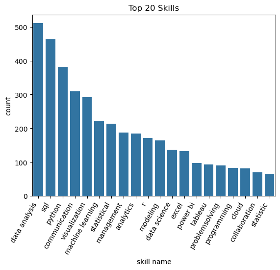

```python
# visualize top 20 in demanding skills
def plot_top_skill(df, col):
    ax = sns.barplot(data=df.head(20), x=col, y='count', errorbar=None)
    format_plot(ax, title='Top 20 Skills', xlabel='skill name', ylabel='count')
    plt.savefig("skill_word_count.png", dpi=300, bbox_inches="tight")
    plt.show()

plot_top_skill(word_count_df, 'word')
```

### 2. K-means Clustering

```python
exploded_df = pd.read_csv('exploded_df.csv', index_col=[0])
# exploded_df.head()
```

```python
exploded_df['cleaned_required_skills'].info()
```

```
<class 'pandas.core.series.Series'>
Int64Index: 6826 entries, 0 to 1510
Series name: cleaned_required_skills
Non-Null Count  Dtype
--------------  -----
6826 non-null   object
dtypes: object(1)
memory usage: 106.7+ KB
```

```python
# %run job_utils.ipynb
exploded_df['cluster'] = KMeans_words(n=100, df=exploded_df['cleaned_required_skills'])
grouped_skills = exploded_df.groupby(['cluster', 'simplified_job_title'])['cleaned_required_skills'].apply(list).reset_index()
grouped_skills
```

|  | cluster | simplified_job_title | cleaned_required_skills |
| --- | --- | --- | --- |
| 0 | 0 | Data Analyst | [aml] |
| 1 | 0 | Data Scientist | [aml] |
| 2 | 1 | Business Intelligence | [data visualization, data visualization, data ... |
| 3 | 1 | Data Analyst | [data visualization, data visualization, data ... |
| 4 | 1 | Data Scientist | [data visualization, data visualization, data ... |
| ... | ... | ... | ... |
| 304 | 98 | Data Scientist | [azure data factory, devops, azure, devops pra... |
| 305 | 98 | Intern | [devops, devops, devops] |
| 306 | 99 | Data Analyst | [report presentation, presentation, powerpoint... |
| 307 | 99 | Data Scientist | [presentation skill, presentation, presentatio... |
| 308 | 99 | Intern | [presentation, presentation skill, presentatio... |

309 rows × 3 columns

```python
# %run job_utils.ipynb
grouped_skills['count'] = grouped_skills['cleaned_required_skills'].apply(len)
grouped_skills['most_freq_skill'] = grouped_skills['cleaned_required_skills'].apply(most_frequent_word)
grouped_skills
```

|  | cluster | simplified_job_title | cleaned_required_skills | count | most_freq_skill |
| --- | --- | --- | --- | --- | --- |
| 0 | 0 | Data Analyst | [aml] | 1 | aml |
| 1 | 0 | Data Scientist | [aml] | 1 | aml |
| 2 | 1 | Business Intelligence | [data visualization, data visualization, data ... | 24 | data visualization |
| 3 | 1 | Data Analyst | [data visualization, data visualization, data ... | 131 | data visualization |
| 4 | 1 | Data Scientist | [data visualization, data visualization, data ... | 116 | data visualization |
| ... | ... | ... | ... | ... | ... |
| 304 | 98 | Data Scientist | [azure data factory, devops, azure, devops pra... | 17 | azure |
| 305 | 98 | Intern | [devops, devops, devops] | 3 | devops |
| 306 | 99 | Data Analyst | [report presentation, presentation, powerpoint... | 14 | presentation skill |
| 307 | 99 | Data Scientist | [presentation skill, presentation, presentatio... | 5 | presentation |
| 308 | 99 | Intern | [presentation, presentation skill, presentatio... | 4 | presentation skill |

309 rows × 5 columns

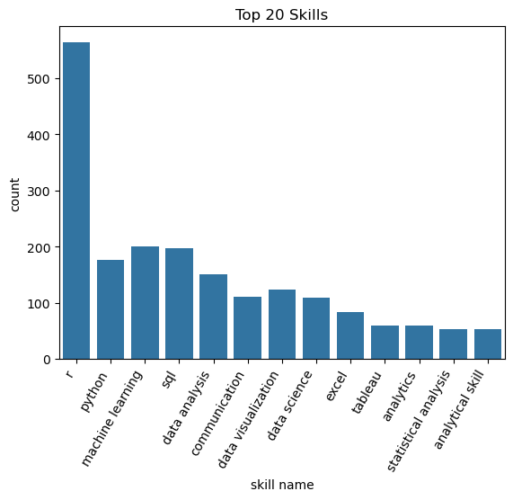

```python
top_skills = grouped_skills.groupby(['most_freq_skill', 'simplified_job_title'])['count'].sum().reset_index()
top_skills = top_skills.sort_values(by='count', ascending=False).head(20)

plot_top_skill(top_skills, col='most_freq_skill')
```

```python
# count of 'r' doesn't make sense
for w in ['r', 'sql', 'python']:
    print(f'number of {w}: ', len(exploded_df[exploded_df['cleaned_required_skills']==w]))
# only 167 'r' exist in exploeded skills
```

```
number of r:  167
number of sql:  440
number of python:  373
```

```python
grouped_skills[grouped_skills['most_freq_skill']=='r']['count'].sum()
```

```
1735
```

Attempted solutions:

1. add context specific qualifiers to the words, like 'r language' and 'c++ language'.
2. tune the number of clusters, there is a trade off here: high number of clusters can have clusters with less different words in them but some similar words may get into different clusters. low number of clusters are vice versa.
3. add a threshold to the percentage of most frequent word in the cluster, for instance, if the most frequent word is less than 50% of the cluster, this cluster is excluded from the calculation.

```python
exploded_df['cleaned_required_skills'].info()
```

[output not shown]

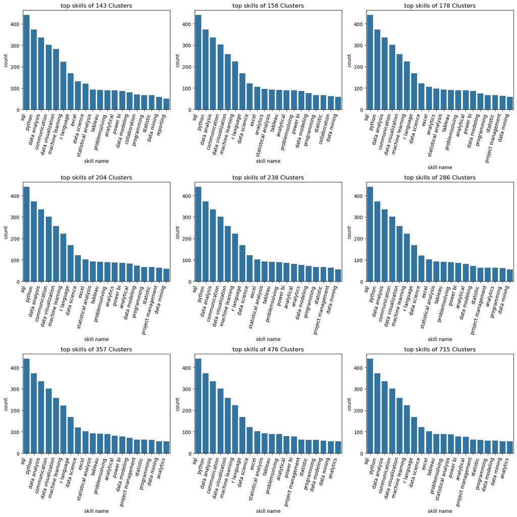

```python
# %run utils.ipynb
tune_num_clusters(exploded_df)
```

The solutions listed above works well, and looks like the number of clusters doesn't matter much for the top 20 skills. The threshold solution works the best.

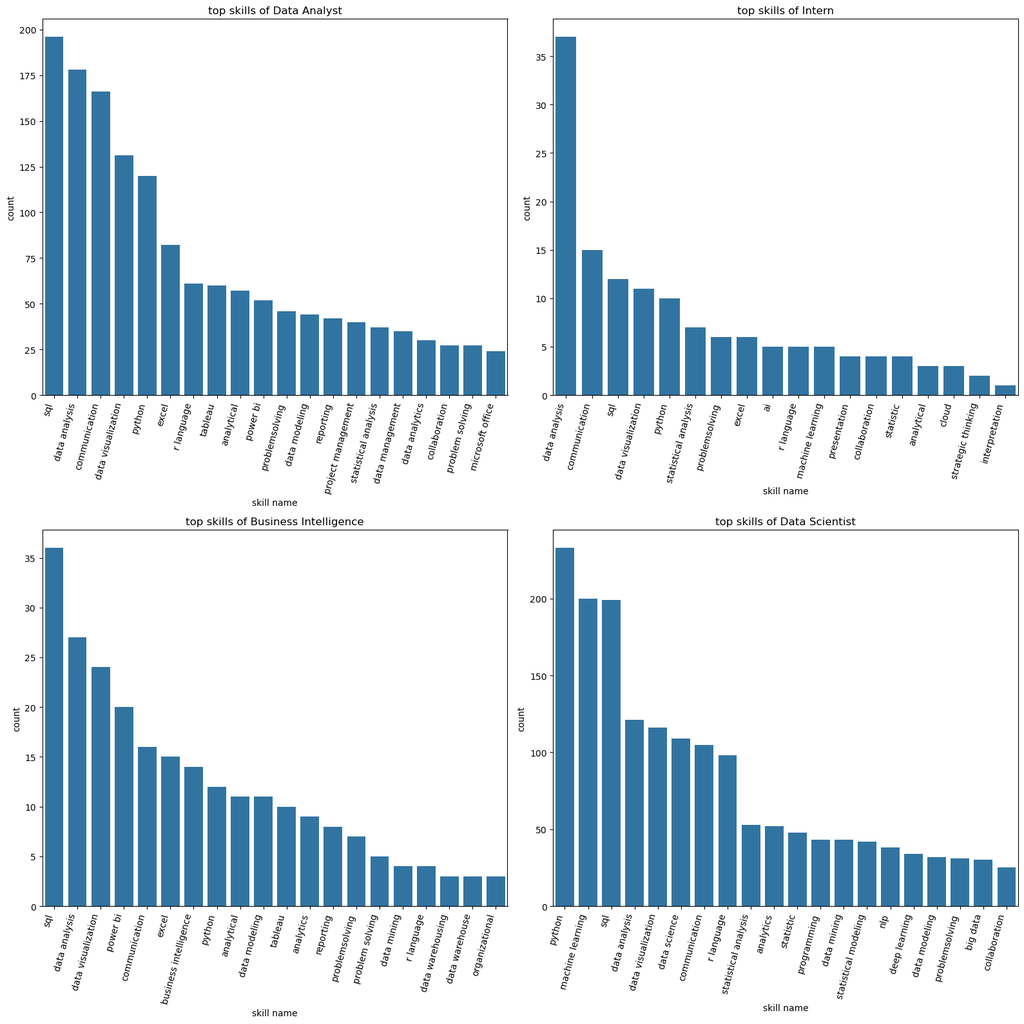

```python
# plot most sorted after skills of different job title
plot_skills_by_title(exploded_df)
```

```python
top_skills_cluster = get_top_skills(200, exploded_df)
```

### Group the Skill Names by Fusszy Match

```python
exploded_df = pd.read_csv('exploded_df.csv', index_col=[0])
```

```python
# Apply the function on the 'skills' column to group similar skills
grouped_skills = skills_fuzzymatch(exploded_df['cleaned_required_skills'], threshold=80)

# Add a new column for grouped skills
exploded_df2 = exploded_df[exploded_df['cleaned_required_skills']!='etl'].copy()
exploded_df2['grouped_skill'] = exploded_df2['cleaned_required_skills'].apply(lambda row: assign_group(row, grouped_skills))

exploded_df2['grouped_skill']
```

```
0                             sql
0                   data modeling
0                          python
0              data visualization
0                   communication
                  ...
1510                     ml model
1510                       mlflow
1510                aws sagemaker
1510                collaboration
1510    stakeholder communication
Name: grouped_skill, Length: 6784, dtype: object
```

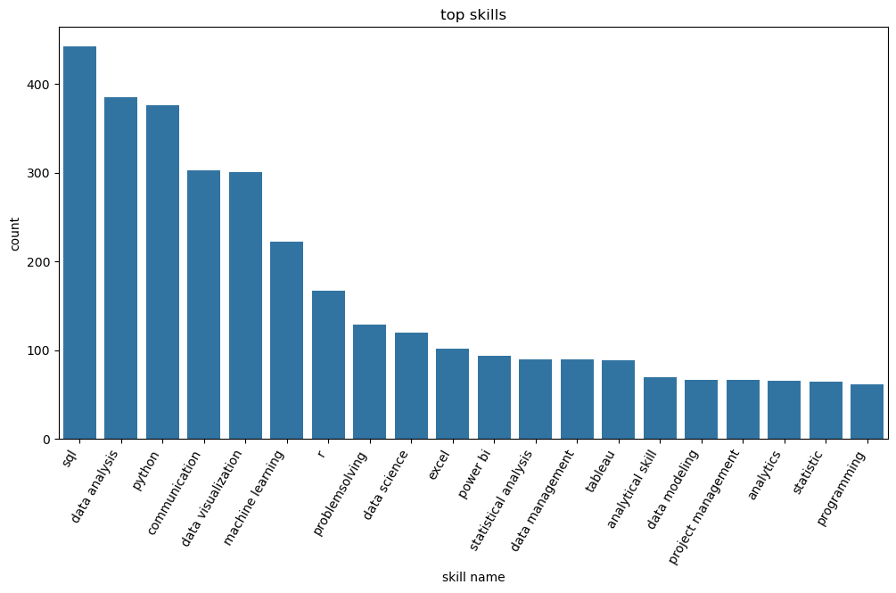

```python
# %run utils.ipynb
top_skills_fuzzymatch = plot_fuzzy_match(exploded_df2)
```

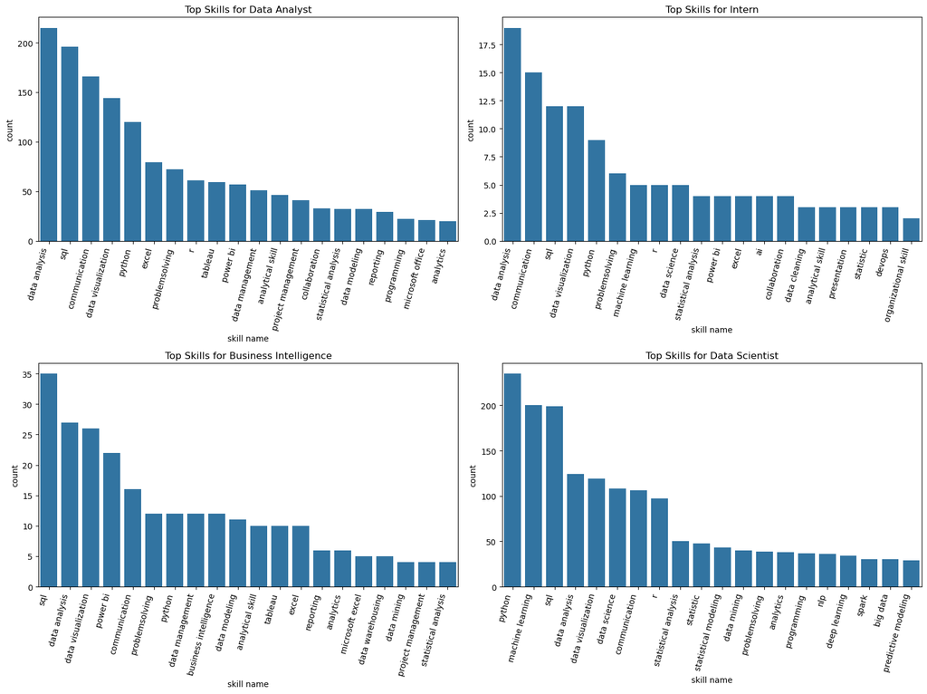

```python
title_list = list(df['simplified_job_title'].unique())

fig, axes = plt.subplots(2, 2, figsize = (16, 12))

for ax, title in zip(axes.flat, title_list):
    df_title = exploded_df2[exploded_df2['simplified_job_title']==title].copy()
    grouped_skills = df_title.groupby('grouped_skill').size().reset_index(name='count')
    top_skills = grouped_skills.sort_values(by='count', ascending=False).head(20)
    sns.barplot(data=top_skills, x='grouped_skill', y='count', ax=ax)
    ax.set_title(f'Top Skills for {title}')
    plt.setp(ax.get_xticklabels(), rotation=75, ha='right')
    ax.set_xlabel('skill name')

plt.tight_layout()
plt.savefig("skill_by_title.png", dpi=300, bbox_inches="tight")
plt.show()
```

Compare all three methods

```python
print(word_count_df.columns)
print(top_skills_cluster.columns)
print(top_skills_fuzzymatch.columns)
```

```
Index(['word', 'count'], dtype='object')
Index(['most_freq_skill', 'count'], dtype='object')
Index(['grouped_skill', 'count'], dtype='object')
```

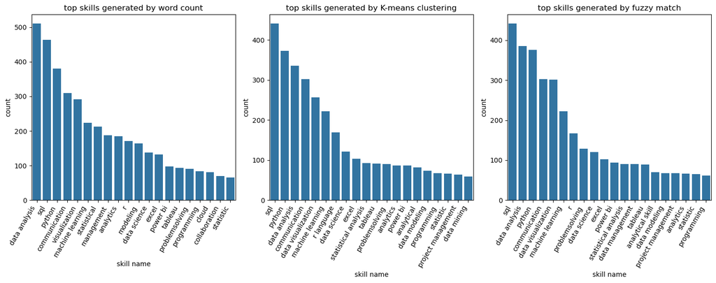

```python
# compare three methods that consolidate similar skill names
fig, axes = plt.subplots(1, 3, figsize=(15, 6))
sns.barplot(data=word_count_df.head(20), x='word', y='count', ax=axes[0])
sns.barplot(data=top_skills_cluster.head(20), x='most_freq_skill', y='count', ax=axes[1])
sns.barplot(data=top_skills_fuzzymatch, x='grouped_skill', y='count', ax=axes[2])

method_list = ['word count', 'K-means clustering', 'fuzzy match']
for ax, method in zip(axes, method_list):
    format_plot(ax, title='top skills generated by '+method, xlabel='skill name')

plt.savefig('skills_compare_three.png', dpi=300, bbox_inches='tight')
plt.tight_layout()
plt.show()
```

Overall, they looks very similar, the most common skills are:

sql, python, communication, data visualization, machine learning, statistic, r, data modeling, excel, power bi, tableau, problem solving, programming, data science

Conclusiong:

1. Word count needs the most human input and preprocessing.
2. K-means clustering is code intensive, need the most computation power and also need some human input to make it work properly.
3. Fuzzy match is the best performing of all three techniques. Needs minimum human input and generate decent report with little coding.
4. Eventough Fuzzy match is the best of all three, the best practice is still make multiple approach so I can have more confidence that the algorithm generate reliable result.
5. This part is the most challenging, yet most fruitful. It proves utilizing AI, machine learning and NLP can quickly extract information from complex dataset. Utilizing these tools can save a lot of time when analyzing the job market and searching jobs.